# lecture 8

Yi Chen(yc3356)

November 16, 2017

## lecture 8

### Distributions and Simulations

1. simple example

Target distribution $p(x=k)=\frac{1}{n}$ for $k=0,1,...,n-1$

instead: generate $U ~ U[0,1]$

```r
set.seed(1)
n <- 10
samp <- 100

head(runif(samp),3);
```

```
## [1] 0.2655087 0.3721239 0.5728534
```

```r
head(n*runif(samp),3);
```

```
## [1] 6.547239 3.531973 2.702601
```

```r
head(floor(n*runif(samp)),3);
```

```
## [1] 2 2 5
```

```r
table(floor(n*runif(samp)))/samp
```

```
##
##    0    1    2    3    4    5    6    7    8    9
## 0.07 0.13 0.10 0.12 0.15 0.06 0.07 0.07 0.11 0.12
```

```r
table(floor(n*runif(samp)))/samp
```

```
##
##    0    1    2    3    4    5    6    7    8    9
## 0.12 0.12 0.05 0.09 0.15 0.07 0.08 0.09 0.09 0.14
```

2. another example

target distribution

X take values in {1,2,3} with probability (1/2,1/4,1/4)

```r
# method one
n <- 100
samp <- runif(n)
u <- rep(NA, n)
u[which(samp<1/2)]<-1
u[which(samp>1/2 & samp<3/4)]<-2
u[which(samp>3/4)] <- 3
u
```

```
##   [1] 2 2 2 2 1 3 1 3 3 2 3 1 1 2 2 1 2 2 1 2 3 2 1 1 1 3 3 3 3 3 2 1 1 1 1
##  [36] 1 1 1 1 2 1 3 2 1 1 1 3 1 2 2 3 2 1 3 3 1 1 1 3 3 2 1 1 2 3 2 1 2 1 3
##  [71] 1 1 1 1 3 2 2 1 3 2 1 3 2 1 2 1 1 2 3 2 2 1 3 2 3 2 1 1 1 1
```

### inverse transform method

1. find the inverse function of the cmf $F^{-1}(P)=inf{ x F(X) U } $
2. generate the random variable follow the uniform distribution
3. plug in the value into the inverse function and calculate the inverse function about the x and p

**exmaple: generate the random variable that follow the exponential distritution with rate = 2** for the exponential distritbuion: $f(x)=\lambda e^{- \lambda x }$

$F(x)=1-e^{-\lambda x}$

then we get

$x=-\frac{1}{\lambda}log(1-u)$

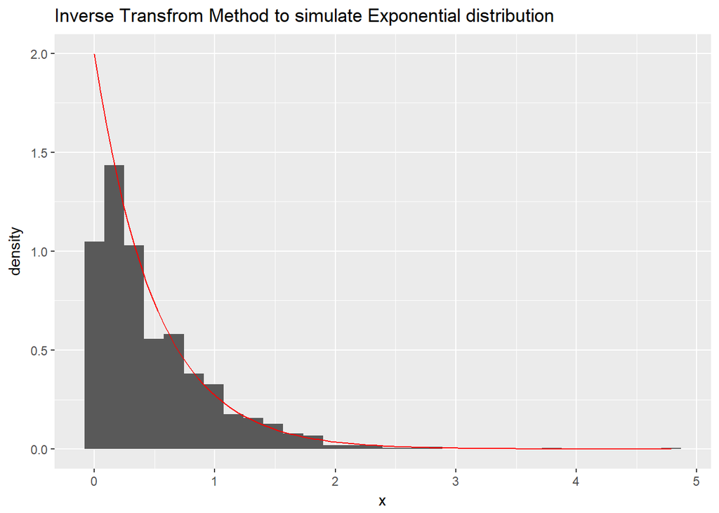

```r
lambda <- 2 # the parameter of the exponential distribution
n <- 1000  # number of random variables
u <- runif(n) # generate the uniform distribution

Finverse <- function(u,lambda){
        # function for the inverse transform
        stopifnot(u > 0 & u < 1)
        return(-(1/lambda)*log(1-u))
}

x <- Finverse(u,lambda)

library(ggplot2)
ggplot(data=data.frame(x))+
        geom_histogram(aes(x=x,y=..density..))+
        stat_function(mapping = aes(x=x),fun = dexp,args = list(rate=2),col='red')+
        labs(title='Inverse Transfrom Method to simulate Exponential distribution')
```

**tesk**

simulate a r.v. of size 1000 from the pdf $f_X(x)=3x^{2},0\leqslant x \leqslant 1$

1. Find the cmf $F_x(x)=x^3$
2. Find the quantile function $F^{-1}_X(x)= x^{1/3}$

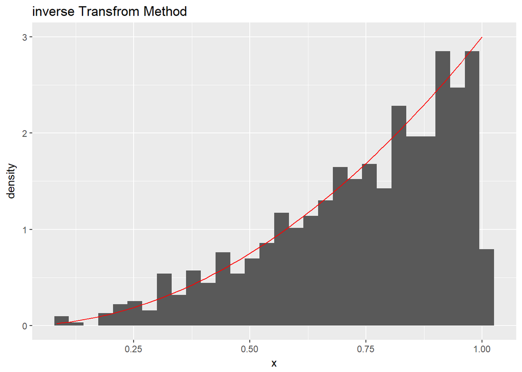

```r
n <- 1000
u <- runif(n)

Finverse <- function(u){
        stopifnot(u > 0 & u < 1)
        return(u^(1/3)) # Inverse function of F(x)
}

x <- Finverse(u)

ggplot(data = data.frame(x))+
        geom_histogram(aes(x=x,y=..density..))+
        stat_function(mapping = aes(x=x),fun = function(x){3*x^2},col='red')+
        labs(title='inverse Transfrom Method')
```

### acceptance regection algorithm

1. **input:**

A probability density $g(x)$ (the proposal density) Proposal density would be provided. A function with $p(x)$ follows the uniform distribution U[0,b]. Here b is the maximum value of proposal density.(the accepetance probability)

2. **random values**

$X_n i.i.d g(x)$

$U_n i.id U[0,1]$

3. **output**

$f(x)=\frac{1}{x}p(x)g(x), where z=\int p(x)g(x)dx$ In reality, f(x) can not be calculated or hard to calculated. That is why we need to use this method.

4 **algorithm** generate $X_n \sim g$ and $U_n \sim U[0,1]$

if $U_n \leqslant P(X_n)$ then output x

The result X we generate would follow the f(x) even though, we do not know the exact function of f(x).

Example:

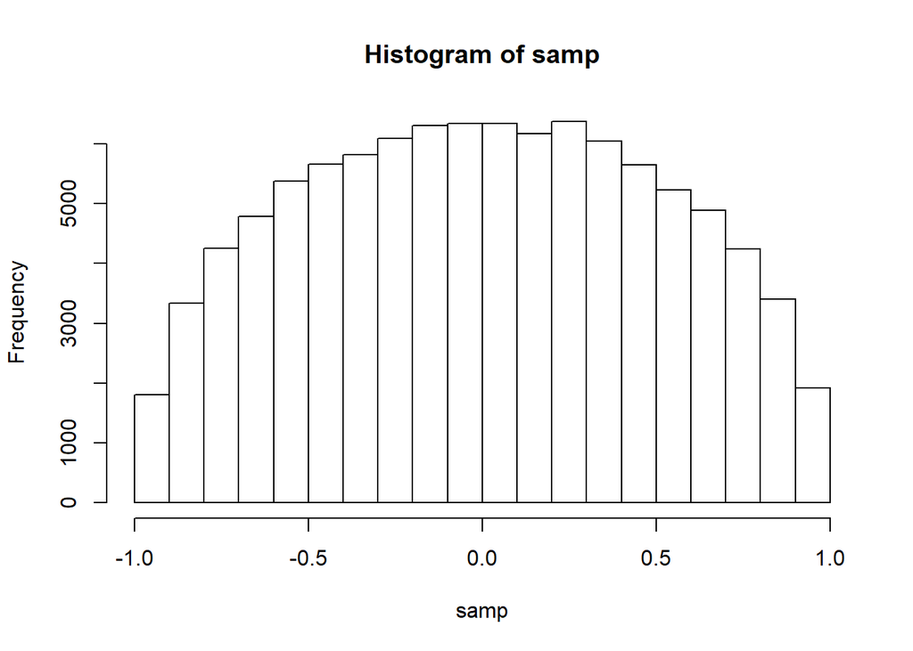

```r
p <- function(x) {sqrt(1 - x^2)}

generate_one <- function(p_func) {
        val <- NULL

        while (is.null(val)) {
                x <- runif(1, min = -1, max = +1)
                u <- runif(1)

                if (u <= p_func(x)) {val <- x}
        }
        return(val)
}


num <- 100000
samp <- rep(NA, num)
for (i in 1:num) {samp[i] <- generate_one(p)}
hist(samp)
```

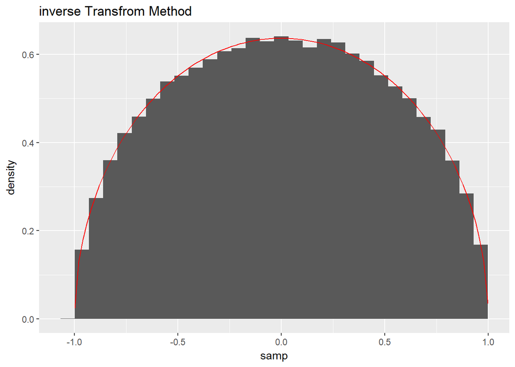

```r
ggplot(data = data.frame(samp))+
        geom_histogram(aes(x=samp,y=..density..))+
        stat_function(mapping = aes(x=samp),fun = function(x){(2/pi)*sqrt(1-x^2)} ,col='red')+
        labs(title='inverse Transfrom Method')
```

Geometric Idea

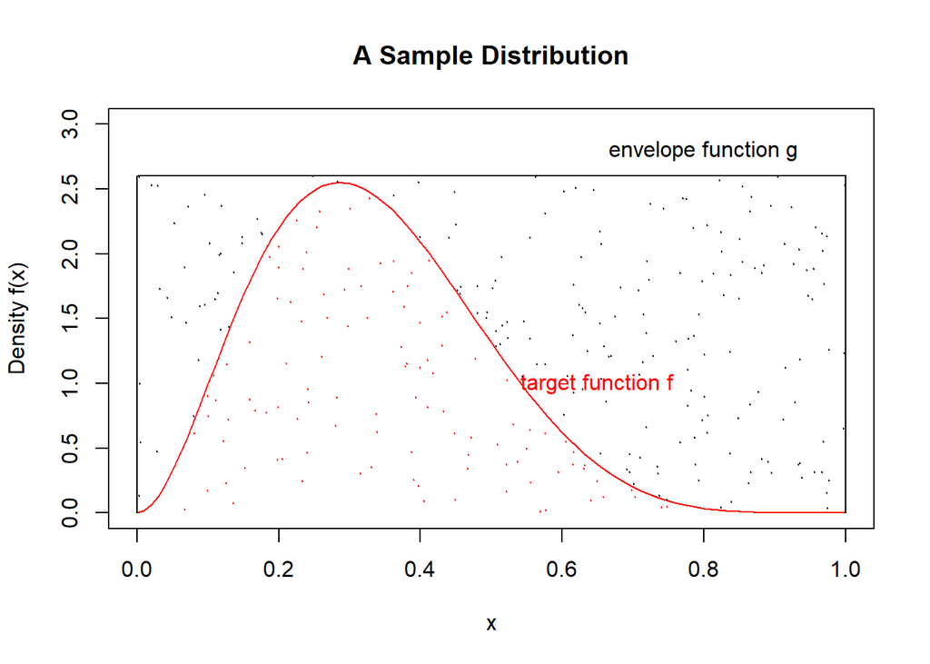

```r
plot(c(0,1), c(0,3), ty = "n", main = "A Sample Distribution",ylab = "Density f(x)", xlab = "x")
curve (dbeta(x, 3, 6), add = TRUE, col = "red")
text(.65, 1, "target function f", col = "red")
text(.8, 2.8, "envelope function g")
lines(c(0,0,1,1), c(0,2.6,2.6,0))  # c(0,0,1,) means the x value, c(0,2.6,2.6,0 means y value)
x1 <- runif(300, min = 0, max = 1);
y1 <- runif(300, min = 0, max = 2.6)
selected <- y1 < dbeta(x1, 3, 6)
points (x1, y1, col = 1+selected, cex = 0.1)
```

**analysis** when calculate $p(x \leq a)=E(X \leq a)=mean(x \leq a)= \int^{a}_{-\infty} f(x) dx=F_X(a)$

```r
mean(selected) # Proportion selected
```

```
## [1] 0.3633333
```

```r
accepted.points <- x1[selected]
# Proportion of sample points less than 0.5.
mean(accepted.points < 0.5)
```

```
## [1] 0.7614679
```

```r
# The true distribution.
pbeta(0.5, 3, 6)
```

```
## [1] 0.8554688
```

```r
plot(c(0,1), c(0,10), ty = "n", main = "A Sample Distribution",
ylab = "Density f(x)", xlab = "x")
curve (dbeta(x, 3, 6), add = TRUE, col = "red")
lines(c(0,0,1,1), c(0,10,10,0))
x2 <- runif(10000, 0, 1)
y2 <- runif(10000, 0, 10)
selected <- y2 < dbeta(x2, 3, 6)
mean(selected) # Proportion selected
```

```
## [1] 0.1008
```

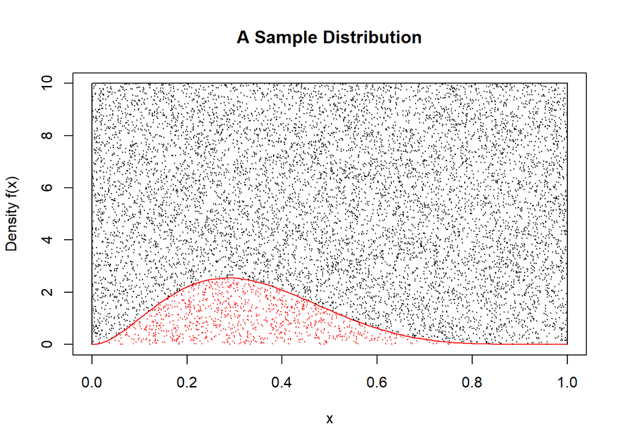

```r
points (x2, y2, col = 1+selected, cex = 0.1)
```

**example**

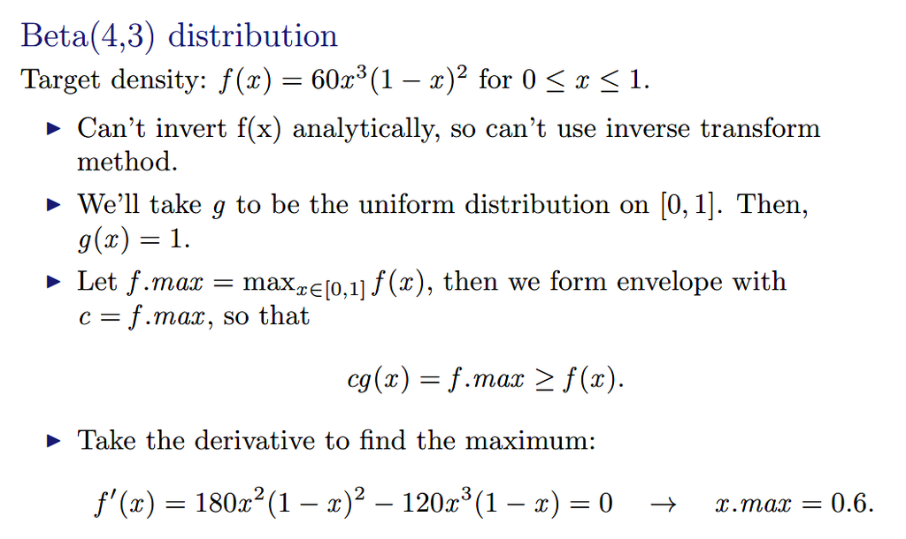